# new

```python
import pandas as pd
import numpy as np
import seaborn as sns
import matplotlib.pyplot as plt
%matplotlib inline
import warnings
warnings.filterwarnings('ignore')
```

```python
## Loading Loan_Details
loan_details = pd.read_csv('Loan_Details_transactions.csv')
pd.set_option('display.max_columns', None)
loan_details.head()
```

|  | Loan_Id | Disbursed_Amount | Asset_Cost | ltv | Branch_Id | City_Code | State_Code | Postal_Code | Date_of_Birth | Employment_Type | DisbursalDate | MobileNo_Avl_Flag | Aadhar_flag | PAN_flag | VoterID_flag | Driving_flag | Passport_flag | PERFORM_CNS.SCORE | DELINQUENT.ACCTS.IN.LAST.SIX.MONTHS | CREDIT.HISTORY.LENGTH | NO.OF_INQUIRIES |
| --- | --- | --- | --- | --- | --- | --- | --- | --- | --- | --- | --- | --- | --- | --- | --- | --- | --- | --- | --- | --- | --- |
| 0 | 1 | 36439 | 65850 | 56.19 | 64 | CT01 | ST15 | 400001 | 14-06-1990 | Self employed | 28-09-2018 | 1 | 1 | 0 | 0 | 0 | 0 | 0 | 0 | 0yrs 0mon | 0 |
| 1 | 2 | 48749 | 69303 | 72.15 | 67 | CT03 | ST24 | 600020 | 01-01-1991 | Salaried | 10-09-2018 | 1 | 1 | 0 | 0 | 0 | 0 | 783 | 0 | 2yrs 6mon | 0 |
| 2 | 3 | 55348 | 66340 | 85.00 | 2 | CT13 | ST04 | 801110 | 16-08-1993 | Self employed | 31-08-2018 | 1 | 1 | 0 | 0 | 0 | 0 | 0 | 0 | 0yrs 0mon | 0 |
| 3 | 4 | 48849 | 64133 | 77.96 | 217 | CT06 | ST22 | 302029 | 01-01-1989 | Self employed | 13-10-2018 | 1 | 1 | 0 | 0 | 0 | 0 | 0 | 0 | 0yrs 0mon | 0 |
| 4 | 5 | 40394 | 59386 | 70.72 | 74 | CT03 | ST24 | 600020 | 31-12-1974 | Self employed | 14-09-2018 | 1 | 1 | 0 | 0 | 0 | 0 | 14 | 1 | 3yrs 1mon | 1 |

```python
## Loading Loan_status_mapping
loan_status_mapping = pd.read_csv('Loan_status_mapping.csv')
loan_status_mapping.head()
```

|  | Loan_Id | Loan_Default |
| --- | --- | --- |
| 0 | 1 | 0 |
| 1 | 2 | 0 |
| 2 | 3 | 1 |
| 3 | 4 | 0 |
| 4 | 5 | 0 |

```python
## Joining loan_details and Loan_staus_mapping
data = loan_details.merge(loan_status_mapping, how = 'left')
data.head()
```

|  | Loan_Id | Disbursed_Amount | Asset_Cost | ltv | Branch_Id | City_Code | State_Code | Postal_Code | Date_of_Birth | Employment_Type | DisbursalDate | MobileNo_Avl_Flag | Aadhar_flag | PAN_flag | VoterID_flag | Driving_flag | Passport_flag | PERFORM_CNS.SCORE | DELINQUENT.ACCTS.IN.LAST.SIX.MONTHS | CREDIT.HISTORY.LENGTH | NO.OF_INQUIRIES | Loan_Default |
| --- | --- | --- | --- | --- | --- | --- | --- | --- | --- | --- | --- | --- | --- | --- | --- | --- | --- | --- | --- | --- | --- | --- |
| 0 | 1 | 36439 | 65850 | 56.19 | 64 | CT01 | ST15 | 400001 | 14-06-1990 | Self employed | 28-09-2018 | 1 | 1 | 0 | 0 | 0 | 0 | 0 | 0 | 0yrs 0mon | 0 | 0 |
| 1 | 2 | 48749 | 69303 | 72.15 | 67 | CT03 | ST24 | 600020 | 01-01-1991 | Salaried | 10-09-2018 | 1 | 1 | 0 | 0 | 0 | 0 | 783 | 0 | 2yrs 6mon | 0 | 0 |
| 2 | 3 | 55348 | 66340 | 85.00 | 2 | CT13 | ST04 | 801110 | 16-08-1993 | Self employed | 31-08-2018 | 1 | 1 | 0 | 0 | 0 | 0 | 0 | 0 | 0yrs 0mon | 0 | 1 |
| 3 | 4 | 48849 | 64133 | 77.96 | 217 | CT06 | ST22 | 302029 | 01-01-1989 | Self employed | 13-10-2018 | 1 | 1 | 0 | 0 | 0 | 0 | 0 | 0 | 0yrs 0mon | 0 | 0 |
| 4 | 5 | 40394 | 59386 | 70.72 | 74 | CT03 | ST24 | 600020 | 31-12-1974 | Self employed | 14-09-2018 | 1 | 1 | 0 | 0 | 0 | 0 | 14 | 1 | 3yrs 1mon | 1 | 0 |

```python
## Loading Branch_ID_Master
branch_id_master = pd.read_csv('Branch_ID_Master.csv')
branch_id_master.head()
```

|  | Branch_Id | Region_Code |
| --- | --- | --- |
| 0 | 1 | R3 |
| 1 | 2 | R3 |
| 2 | 3 | R3 |
| 3 | 5 | R3 |
| 4 | 7 | R3 |

```python
## merge branch_id_master
data = data.merge(branch_id_master, how = 'left')
data.head()
```

|  | Loan_Id | Disbursed_Amount | Asset_Cost | ltv | Branch_Id | City_Code | State_Code | Postal_Code | Date_of_Birth | Employment_Type | DisbursalDate | MobileNo_Avl_Flag | Aadhar_flag | PAN_flag | VoterID_flag | Driving_flag | Passport_flag | PERFORM_CNS.SCORE | DELINQUENT.ACCTS.IN.LAST.SIX.MONTHS | CREDIT.HISTORY.LENGTH | NO.OF_INQUIRIES | Loan_Default | Region_Code |
| --- | --- | --- | --- | --- | --- | --- | --- | --- | --- | --- | --- | --- | --- | --- | --- | --- | --- | --- | --- | --- | --- | --- | --- |
| 0 | 1 | 36439 | 65850 | 56.19 | 64 | CT01 | ST15 | 400001 | 14-06-1990 | Self employed | 28-09-2018 | 1 | 1 | 0 | 0 | 0 | 0 | 0 | 0 | 0yrs 0mon | 0 | 0 | R2 |
| 1 | 2 | 48749 | 69303 | 72.15 | 67 | CT03 | ST24 | 600020 | 01-01-1991 | Salaried | 10-09-2018 | 1 | 1 | 0 | 0 | 0 | 0 | 783 | 0 | 2yrs 6mon | 0 | 0 | R2 |
| 2 | 3 | 55348 | 66340 | 85.00 | 2 | CT13 | ST04 | 801110 | 16-08-1993 | Self employed | 31-08-2018 | 1 | 1 | 0 | 0 | 0 | 0 | 0 | 0 | 0yrs 0mon | 0 | 1 | R3 |
| 3 | 4 | 48849 | 64133 | 77.96 | 217 | CT06 | ST22 | 302029 | 01-01-1989 | Self employed | 13-10-2018 | 1 | 1 | 0 | 0 | 0 | 0 | 0 | 0 | 0yrs 0mon | 0 | 0 | R1 |
| 4 | 5 | 40394 | 59386 | 70.72 | 74 | CT03 | ST24 | 600020 | 31-12-1974 | Self employed | 14-09-2018 | 1 | 1 | 0 | 0 | 0 | 0 | 14 | 1 | 3yrs 1mon | 1 | 0 | R2 |

```python
## Loading City_Master
city_master = pd.read_excel('City_Master.xlsx')
city_master.head()
```

|  | City_Code | State_Code | City_Name |
| --- | --- | --- | --- |
| 0 | CT01 | ST15 | Mumbai |
| 1 | CT02 | ST15 | Pune |
| 2 | CT03 | ST24 | Chennai |
| 3 | CT04 | ST24 | Coimbatore |
| 4 | CT05 | ST25 | Hyderabad |

```python
## merging City_Master
data = data.merge(city_master, how = 'left')
data.head()
```

|  | Loan_Id | Disbursed_Amount | Asset_Cost | ltv | Branch_Id | City_Code | State_Code | Postal_Code | Date_of_Birth | Employment_Type | DisbursalDate | MobileNo_Avl_Flag | Aadhar_flag | PAN_flag | VoterID_flag | Driving_flag | Passport_flag | PERFORM_CNS.SCORE | DELINQUENT.ACCTS.IN.LAST.SIX.MONTHS | CREDIT.HISTORY.LENGTH | NO.OF_INQUIRIES | Loan_Default | Region_Code | City_Name |
| --- | --- | --- | --- | --- | --- | --- | --- | --- | --- | --- | --- | --- | --- | --- | --- | --- | --- | --- | --- | --- | --- | --- | --- | --- |
| 0 | 1 | 36439 | 65850 | 56.19 | 64 | CT01 | ST15 | 400001 | 14-06-1990 | Self employed | 28-09-2018 | 1 | 1 | 0 | 0 | 0 | 0 | 0 | 0 | 0yrs 0mon | 0 | 0 | R2 | Mumbai |
| 1 | 2 | 48749 | 69303 | 72.15 | 67 | CT03 | ST24 | 600020 | 01-01-1991 | Salaried | 10-09-2018 | 1 | 1 | 0 | 0 | 0 | 0 | 783 | 0 | 2yrs 6mon | 0 | 0 | R2 | Chennai |
| 2 | 3 | 55348 | 66340 | 85.00 | 2 | CT13 | ST04 | 801110 | 16-08-1993 | Self employed | 31-08-2018 | 1 | 1 | 0 | 0 | 0 | 0 | 0 | 0 | 0yrs 0mon | 0 | 1 | R3 | Patna |
| 3 | 4 | 48849 | 64133 | 77.96 | 217 | CT06 | ST22 | 302029 | 01-01-1989 | Self employed | 13-10-2018 | 1 | 1 | 0 | 0 | 0 | 0 | 0 | 0 | 0yrs 0mon | 0 | 0 | R1 | Jaipur |
| 4 | 5 | 40394 | 59386 | 70.72 | 74 | CT03 | ST24 | 600020 | 31-12-1974 | Self employed | 14-09-2018 | 1 | 1 | 0 | 0 | 0 | 0 | 14 | 1 | 3yrs 1mon | 1 | 0 | R2 | Chennai |

```python
## Loading Postal_Code_Master
postal_code_master = pd.read_excel('Postal_Code_Master.xlsx')
postal_code_master.head()
```

|  | City_Code | City_Name | Postal_Code |
| --- | --- | --- | --- |
| 0 | CT01 | Mumbai | 400001 |
| 1 | CT01 | Mumbai | 400053 |
| 2 | CT01 | Mumbai | 422001 |
| 3 | CT02 | Pune | 411002 |
| 4 | CT02 | Pune | 411006 |

```python
## loading State_Master
state_master = pd.read_excel('State_Master.xlsx')
state_master.head()
```

|  | State_Code | State_Name |
| --- | --- | --- |
| 0 | ST01 | Andhra Pradesh |
| 1 | ST02 | Arunachal Pradesh |
| 2 | ST03 | Assam |
| 3 | ST04 | Bihar |
| 4 | ST05 | Chhattisgarh |

```python
data
```

|  | Loan_Id | Disbursed_Amount | Asset_Cost | ltv | Branch_Id | City_Code | State_Code | Postal_Code | Date_of_Birth | Employment_Type | DisbursalDate | MobileNo_Avl_Flag | Aadhar_flag | PAN_flag | VoterID_flag | Driving_flag | Passport_flag | PERFORM_CNS.SCORE | DELINQUENT.ACCTS.IN.LAST.SIX.MONTHS | CREDIT.HISTORY.LENGTH | NO.OF_INQUIRIES | Loan_Default | Region_Code | City_Name |
| --- | --- | --- | --- | --- | --- | --- | --- | --- | --- | --- | --- | --- | --- | --- | --- | --- | --- | --- | --- | --- | --- | --- | --- | --- |
| 0 | 1 | 36439 | 65850 | 56.19 | 64 | CT01 | ST15 | 400001 | 14-06-1990 | Self employed | 28-09-2018 | 1 | 1 | 0 | 0 | 0 | 0 | 0 | 0 | 0yrs 0mon | 0 | 0 | R2 | Mumbai |
| 1 | 2 | 48749 | 69303 | 72.15 | 67 | CT03 | ST24 | 600020 | 01-01-1991 | Salaried | 10-09-2018 | 1 | 1 | 0 | 0 | 0 | 0 | 783 | 0 | 2yrs 6mon | 0 | 0 | R2 | Chennai |
| 2 | 3 | 55348 | 66340 | 85.00 | 2 | CT13 | ST04 | 801110 | 16-08-1993 | Self employed | 31-08-2018 | 1 | 1 | 0 | 0 | 0 | 0 | 0 | 0 | 0yrs 0mon | 0 | 1 | R3 | Patna |
| 3 | 4 | 48849 | 64133 | 77.96 | 217 | CT06 | ST22 | 302029 | 01-01-1989 | Self employed | 13-10-2018 | 1 | 1 | 0 | 0 | 0 | 0 | 0 | 0 | 0yrs 0mon | 0 | 0 | R1 | Jaipur |
| 4 | 5 | 40394 | 59386 | 70.72 | 74 | CT03 | ST24 | 600020 | 31-12-1974 | Self employed | 14-09-2018 | 1 | 1 | 0 | 0 | 0 | 0 | 14 | 1 | 3yrs 1mon | 1 | 0 | R2 | Chennai |
| ... | ... | ... | ... | ... | ... | ... | ... | ... | ... | ... | ... | ... | ... | ... | ... | ... | ... | ... | ... | ... | ... | ... | ... | ... |
| 23310 | 23311 | 123661 | 185371 | 69.59 | 34 | CT03 | ST24 | 600020 | 14-12-1982 | Self employed | 26-08-2018 | 1 | 1 | 0 | 0 | 0 | 0 | 650 | 0 | 5yrs 10mon | 1 | 0 | R3 | Chennai |
| 23311 | 23312 | 78879 | 122878 | 65.11 | 5 | CT15 | ST20 | 751022 | 03-07-1993 | Salaried | 23-09-2018 | 1 | 1 | 0 | 0 | 0 | 0 | 680 | 0 | 0yrs 9mon | 0 | 0 | R3 | Bhubaneshwar |
| 23312 | 23313 | 49349 | 67695 | 73.86 | 48 | CT22 | ST14 | 453551 | 01-01-1994 | Self employed | 23-10-2018 | 1 | 1 | 0 | 0 | 0 | 0 | 825 | 0 | 2yrs 3mon | 0 | 0 | R2 | Indore |
| 23313 | 23314 | 70897 | 84400 | 86.00 | 2 | CT03 | ST24 | 600020 | 10-10-1982 | Self employed | 25-08-2018 | 1 | 1 | 0 | 0 | 0 | 0 | 657 | 0 | 0yrs 6mon | 2 | 0 | R3 | Chennai |
| 23314 | 23315 | 58206 | 71372 | 85.00 | 34 | CT09 | ST34 | 110039 | 01-02-1976 | Self employed | 03-10-2018 | 1 | 1 | 0 | 0 | 0 | 0 | 529 | 0 | 3yrs 11mon | 0 | 0 | R3 | Delhi |

23315 rows × 24 columns

# Problem Statement

Here in this data set there are various attribute realted to bank loan. And our objective is to make models to predict the cuatomer will Loan_default or not.

```python
## merge State_name
data = data.merge(state_master, how = 'left')
data.head()
```

|  | Loan_Id | Disbursed_Amount | Asset_Cost | ltv | Branch_Id | City_Code | State_Code | Postal_Code | Date_of_Birth | Employment_Type | DisbursalDate | MobileNo_Avl_Flag | Aadhar_flag | PAN_flag | VoterID_flag | Driving_flag | Passport_flag | PERFORM_CNS.SCORE | DELINQUENT.ACCTS.IN.LAST.SIX.MONTHS | CREDIT.HISTORY.LENGTH | NO.OF_INQUIRIES | Loan_Default | Region_Code | City_Name | State_Name |
| --- | --- | --- | --- | --- | --- | --- | --- | --- | --- | --- | --- | --- | --- | --- | --- | --- | --- | --- | --- | --- | --- | --- | --- | --- | --- |
| 0 | 1 | 36439 | 65850 | 56.19 | 64 | CT01 | ST15 | 400001 | 14-06-1990 | Self employed | 28-09-2018 | 1 | 1 | 0 | 0 | 0 | 0 | 0 | 0 | 0yrs 0mon | 0 | 0 | R2 | Mumbai | Maharashtra |
| 1 | 2 | 48749 | 69303 | 72.15 | 67 | CT03 | ST24 | 600020 | 01-01-1991 | Salaried | 10-09-2018 | 1 | 1 | 0 | 0 | 0 | 0 | 783 | 0 | 2yrs 6mon | 0 | 0 | R2 | Chennai | Tamil Nadu |
| 2 | 3 | 55348 | 66340 | 85.00 | 2 | CT13 | ST04 | 801110 | 16-08-1993 | Self employed | 31-08-2018 | 1 | 1 | 0 | 0 | 0 | 0 | 0 | 0 | 0yrs 0mon | 0 | 1 | R3 | Patna | Bihar |
| 3 | 4 | 48849 | 64133 | 77.96 | 217 | CT06 | ST22 | 302029 | 01-01-1989 | Self employed | 13-10-2018 | 1 | 1 | 0 | 0 | 0 | 0 | 0 | 0 | 0yrs 0mon | 0 | 0 | R1 | Jaipur | Rajasthan |
| 4 | 5 | 40394 | 59386 | 70.72 | 74 | CT03 | ST24 | 600020 | 31-12-1974 | Self employed | 14-09-2018 | 1 | 1 | 0 | 0 | 0 | 0 | 14 | 1 | 3yrs 1mon | 1 | 0 | R2 | Chennai | Tamil Nadu |

## Data Cleaning and Preprocessing

```python
data.info()
```

```
<class 'pandas.core.frame.DataFrame'>
Int64Index: 23315 entries, 0 to 23314
Data columns (total 25 columns):
 #   Column                               Non-Null Count  Dtype
---  ------                               --------------  -----
 0   Loan_Id                              23315 non-null  int64
 1   Disbursed_Amount                     23315 non-null  int64
 2   Asset_Cost                           23315 non-null  int64
 3   ltv                                  23315 non-null  float64
 4   Branch_Id                            23315 non-null  int64
 5   City_Code                            23315 non-null  object
 6   State_Code                           23315 non-null  object
 7   Postal_Code                          23315 non-null  int64
 8   Date_of_Birth                        23315 non-null  object
 9   Employment_Type                      22545 non-null  object
```

[output cut: 17 more lines]

```python
data.isnull().sum()
```

```
Loan_Id                                  0
Disbursed_Amount                         0
Asset_Cost                               0
ltv                                      0
Branch_Id                                0
City_Code                                0
State_Code                               0
Postal_Code                              0
Date_of_Birth                            0
Employment_Type                        770
DisbursalDate                            0
MobileNo_Avl_Flag                        0
Aadhar_flag                              0
PAN_flag                                 0
VoterID_flag                             0
Driving_flag                             0
Passport_flag                            0
PERFORM_CNS.SCORE                        0
DELINQUENT.ACCTS.IN.LAST.SIX.MONTHS      0
CREDIT.HISTORY.LENGTH                    0
NO.OF_INQUIRIES                          0
Loan_Default                             0
Region_Code                              0
City_Name                                0
State_Name                               0
dtype: int64
```

```python
data.shape
```

```
(23315, 25)
```

*Now, the customers who does not provide employment type will obviously not be eligible for Loan so we will remove records that have null values in Employment_Type.*

```python
data = data.drop(data[(data['Employment_Type'] != 'Self employed') & (data['Employment_Type'] != 'Salaried')].index)
```

```python
data['Employment_Type'].unique()
```

```
array(['Self employed', 'Salaried'], dtype=object)
```

```python
## Dropping irrelavant features
data.drop('State_Code', axis = 1, inplace = True)
data.drop('City_Code', axis = 1, inplace = True)
data.drop('Region_Code', axis = 1, inplace = True)
```

```python
data.drop('Loan_Id', axis = 1, inplace = True)
```

```python
data.head()
```

|  | Disbursed_Amount | Asset_Cost | ltv | Branch_Id | Postal_Code | Date_of_Birth | Employment_Type | DisbursalDate | MobileNo_Avl_Flag | Aadhar_flag | PAN_flag | VoterID_flag | Driving_flag | Passport_flag | PERFORM_CNS.SCORE | DELINQUENT.ACCTS.IN.LAST.SIX.MONTHS | CREDIT.HISTORY.LENGTH | NO.OF_INQUIRIES | Loan_Default | City_Name | State_Name |
| --- | --- | --- | --- | --- | --- | --- | --- | --- | --- | --- | --- | --- | --- | --- | --- | --- | --- | --- | --- | --- | --- |
| 0 | 36439 | 65850 | 56.19 | 64 | 400001 | 14-06-1990 | Self employed | 28-09-2018 | 1 | 1 | 0 | 0 | 0 | 0 | 0 | 0 | 0yrs 0mon | 0 | 0 | Mumbai | Maharashtra |
| 1 | 48749 | 69303 | 72.15 | 67 | 600020 | 01-01-1991 | Salaried | 10-09-2018 | 1 | 1 | 0 | 0 | 0 | 0 | 783 | 0 | 2yrs 6mon | 0 | 0 | Chennai | Tamil Nadu |
| 2 | 55348 | 66340 | 85.00 | 2 | 801110 | 16-08-1993 | Self employed | 31-08-2018 | 1 | 1 | 0 | 0 | 0 | 0 | 0 | 0 | 0yrs 0mon | 0 | 1 | Patna | Bihar |
| 3 | 48849 | 64133 | 77.96 | 217 | 302029 | 01-01-1989 | Self employed | 13-10-2018 | 1 | 1 | 0 | 0 | 0 | 0 | 0 | 0 | 0yrs 0mon | 0 | 0 | Jaipur | Rajasthan |
| 4 | 40394 | 59386 | 70.72 | 74 | 600020 | 31-12-1974 | Self employed | 14-09-2018 | 1 | 1 | 0 | 0 | 0 | 0 | 14 | 1 | 3yrs 1mon | 1 | 0 | Chennai | Tamil Nadu |

```python
# Creating new feature year of birth and dropping Date_of_birth
data['Year_of_birth'] = data['Date_of_Birth'].apply(lambda x: x.split('-')[2])
data.head()
```

|  | Disbursed_Amount | Asset_Cost | ltv | Branch_Id | Postal_Code | Date_of_Birth | Employment_Type | DisbursalDate | MobileNo_Avl_Flag | Aadhar_flag | PAN_flag | VoterID_flag | Driving_flag | Passport_flag | PERFORM_CNS.SCORE | DELINQUENT.ACCTS.IN.LAST.SIX.MONTHS | CREDIT.HISTORY.LENGTH | NO.OF_INQUIRIES | Loan_Default | City_Name | State_Name | Year_of_birth |
| --- | --- | --- | --- | --- | --- | --- | --- | --- | --- | --- | --- | --- | --- | --- | --- | --- | --- | --- | --- | --- | --- | --- |
| 0 | 36439 | 65850 | 56.19 | 64 | 400001 | 14-06-1990 | Self employed | 28-09-2018 | 1 | 1 | 0 | 0 | 0 | 0 | 0 | 0 | 0yrs 0mon | 0 | 0 | Mumbai | Maharashtra | 1990 |
| 1 | 48749 | 69303 | 72.15 | 67 | 600020 | 01-01-1991 | Salaried | 10-09-2018 | 1 | 1 | 0 | 0 | 0 | 0 | 783 | 0 | 2yrs 6mon | 0 | 0 | Chennai | Tamil Nadu | 1991 |
| 2 | 55348 | 66340 | 85.00 | 2 | 801110 | 16-08-1993 | Self employed | 31-08-2018 | 1 | 1 | 0 | 0 | 0 | 0 | 0 | 0 | 0yrs 0mon | 0 | 1 | Patna | Bihar | 1993 |
| 3 | 48849 | 64133 | 77.96 | 217 | 302029 | 01-01-1989 | Self employed | 13-10-2018 | 1 | 1 | 0 | 0 | 0 | 0 | 0 | 0 | 0yrs 0mon | 0 | 0 | Jaipur | Rajasthan | 1989 |
| 4 | 40394 | 59386 | 70.72 | 74 | 600020 | 31-12-1974 | Self employed | 14-09-2018 | 1 | 1 | 0 | 0 | 0 | 0 | 14 | 1 | 3yrs 1mon | 1 | 0 | Chennai | Tamil Nadu | 1974 |

```python
data.drop('Date_of_Birth', axis = 1, inplace = True)
data.head()
```

|  | Disbursed_Amount | Asset_Cost | ltv | Branch_Id | Postal_Code | Employment_Type | DisbursalDate | MobileNo_Avl_Flag | Aadhar_flag | PAN_flag | VoterID_flag | Driving_flag | Passport_flag | PERFORM_CNS.SCORE | DELINQUENT.ACCTS.IN.LAST.SIX.MONTHS | CREDIT.HISTORY.LENGTH | NO.OF_INQUIRIES | Loan_Default | City_Name | State_Name | Year_of_birth |
| --- | --- | --- | --- | --- | --- | --- | --- | --- | --- | --- | --- | --- | --- | --- | --- | --- | --- | --- | --- | --- | --- |
| 0 | 36439 | 65850 | 56.19 | 64 | 400001 | Self employed | 28-09-2018 | 1 | 1 | 0 | 0 | 0 | 0 | 0 | 0 | 0yrs 0mon | 0 | 0 | Mumbai | Maharashtra | 1990 |
| 1 | 48749 | 69303 | 72.15 | 67 | 600020 | Salaried | 10-09-2018 | 1 | 1 | 0 | 0 | 0 | 0 | 783 | 0 | 2yrs 6mon | 0 | 0 | Chennai | Tamil Nadu | 1991 |
| 2 | 55348 | 66340 | 85.00 | 2 | 801110 | Self employed | 31-08-2018 | 1 | 1 | 0 | 0 | 0 | 0 | 0 | 0 | 0yrs 0mon | 0 | 1 | Patna | Bihar | 1993 |
| 3 | 48849 | 64133 | 77.96 | 217 | 302029 | Self employed | 13-10-2018 | 1 | 1 | 0 | 0 | 0 | 0 | 0 | 0 | 0yrs 0mon | 0 | 0 | Jaipur | Rajasthan | 1989 |
| 4 | 40394 | 59386 | 70.72 | 74 | 600020 | Self employed | 14-09-2018 | 1 | 1 | 0 | 0 | 0 | 0 | 14 | 1 | 3yrs 1mon | 1 | 0 | Chennai | Tamil Nadu | 1974 |

```python
data['Year_of_birth'] = data['Year_of_birth'].astype(int)
```

```python
# Creating Age of person and storing in variable Age
data['Age'] = data['Year_of_birth'].apply(lambda x: 2019-x)
```

```python
# fetching date of dibursalDate and creating new variable DisburseDate
data['DisburseDate'] = data['DisbursalDate'].apply(lambda x: x.split('-')[0])
data.head()
```

|  | Disbursed_Amount | Asset_Cost | ltv | Branch_Id | Postal_Code | Employment_Type | DisbursalDate | MobileNo_Avl_Flag | Aadhar_flag | PAN_flag | VoterID_flag | Driving_flag | Passport_flag | PERFORM_CNS.SCORE | DELINQUENT.ACCTS.IN.LAST.SIX.MONTHS | CREDIT.HISTORY.LENGTH | NO.OF_INQUIRIES | Loan_Default | City_Name | State_Name | Year_of_birth | Age | DisburseDate |
| --- | --- | --- | --- | --- | --- | --- | --- | --- | --- | --- | --- | --- | --- | --- | --- | --- | --- | --- | --- | --- | --- | --- | --- |
| 0 | 36439 | 65850 | 56.19 | 64 | 400001 | Self employed | 28-09-2018 | 1 | 1 | 0 | 0 | 0 | 0 | 0 | 0 | 0yrs 0mon | 0 | 0 | Mumbai | Maharashtra | 1990 | 29 | 28 |
| 1 | 48749 | 69303 | 72.15 | 67 | 600020 | Salaried | 10-09-2018 | 1 | 1 | 0 | 0 | 0 | 0 | 783 | 0 | 2yrs 6mon | 0 | 0 | Chennai | Tamil Nadu | 1991 | 28 | 10 |
| 2 | 55348 | 66340 | 85.00 | 2 | 801110 | Self employed | 31-08-2018 | 1 | 1 | 0 | 0 | 0 | 0 | 0 | 0 | 0yrs 0mon | 0 | 1 | Patna | Bihar | 1993 | 26 | 31 |
| 3 | 48849 | 64133 | 77.96 | 217 | 302029 | Self employed | 13-10-2018 | 1 | 1 | 0 | 0 | 0 | 0 | 0 | 0 | 0yrs 0mon | 0 | 0 | Jaipur | Rajasthan | 1989 | 30 | 13 |
| 4 | 40394 | 59386 | 70.72 | 74 | 600020 | Self employed | 14-09-2018 | 1 | 1 | 0 | 0 | 0 | 0 | 14 | 1 | 3yrs 1mon | 1 | 0 | Chennai | Tamil Nadu | 1974 | 45 | 14 |

```python
# fetching month form DisburedDate feature and storinf it in valrible DisbirseMonth
data['DisburseMonth'] = data['DisbursalDate'].apply(lambda x: x.split('-')[1])
```

```python
# fetching year of Disbursaldate and soring in feature DisburseYear and droping DisbursalDate feature
data['DisburseYear'] = data['DisbursalDate'].apply(lambda x: x.split('-')[2])
data.drop('DisbursalDate', axis = 1, inplace = True)
data.head()
```

|  | Disbursed_Amount | Asset_Cost | ltv | Branch_Id | Postal_Code | Employment_Type | MobileNo_Avl_Flag | Aadhar_flag | PAN_flag | VoterID_flag | Driving_flag | Passport_flag | PERFORM_CNS.SCORE | DELINQUENT.ACCTS.IN.LAST.SIX.MONTHS | CREDIT.HISTORY.LENGTH | NO.OF_INQUIRIES | Loan_Default | City_Name | State_Name | Year_of_birth | Age | DisburseDate | DisburseMonth | DisburseYear |
| --- | --- | --- | --- | --- | --- | --- | --- | --- | --- | --- | --- | --- | --- | --- | --- | --- | --- | --- | --- | --- | --- | --- | --- | --- |
| 0 | 36439 | 65850 | 56.19 | 64 | 400001 | Self employed | 1 | 1 | 0 | 0 | 0 | 0 | 0 | 0 | 0yrs 0mon | 0 | 0 | Mumbai | Maharashtra | 1990 | 29 | 28 | 09 | 2018 |
| 1 | 48749 | 69303 | 72.15 | 67 | 600020 | Salaried | 1 | 1 | 0 | 0 | 0 | 0 | 783 | 0 | 2yrs 6mon | 0 | 0 | Chennai | Tamil Nadu | 1991 | 28 | 10 | 09 | 2018 |
| 2 | 55348 | 66340 | 85.00 | 2 | 801110 | Self employed | 1 | 1 | 0 | 0 | 0 | 0 | 0 | 0 | 0yrs 0mon | 0 | 1 | Patna | Bihar | 1993 | 26 | 31 | 08 | 2018 |
| 3 | 48849 | 64133 | 77.96 | 217 | 302029 | Self employed | 1 | 1 | 0 | 0 | 0 | 0 | 0 | 0 | 0yrs 0mon | 0 | 0 | Jaipur | Rajasthan | 1989 | 30 | 13 | 10 | 2018 |
| 4 | 40394 | 59386 | 70.72 | 74 | 600020 | Self employed | 1 | 1 | 0 | 0 | 0 | 0 | 14 | 1 | 3yrs 1mon | 1 | 0 | Chennai | Tamil Nadu | 1974 | 45 | 14 | 09 | 2018 |

```python
data.describe()['NO.OF_INQUIRIES']
```

```
count    22545.000000
mean         0.208472
std          0.704221
min          0.000000
25%          0.000000
50%          0.000000
75%          0.000000
max         23.000000
Name: NO.OF_INQUIRIES, dtype: float64
```

```python
data['NO.OF_INQUIRIES'].value_counts()
```

```
0     19491
1      2184
2       534
3       174
4        66
5        33
7        20
6        18
8         9
9         8
10        4
12        2
18        1
23        1
Name: NO.OF_INQUIRIES, dtype: int64
```

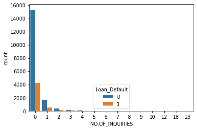

```python
sns.countplot(data['NO.OF_INQUIRIES'], hue = data['Loan_Default'])
```

```python
import re
```

```python
data['CREDIT.HISTORY.LENGTH'] = data['CREDIT.HISTORY.LENGTH'].apply(lambda x: re.sub('yrs', '', x))
```

```python
data['CREDIT.HISTORY.LENGTH'] = data['CREDIT.HISTORY.LENGTH'].apply(lambda x: re.sub('mon', '', x) )
```

```python
data['Ch'] = data['CREDIT.HISTORY.LENGTH'].apply(lambda x: int(x.split()[0]))
data.head()
```

|  | Disbursed_Amount | Asset_Cost | ltv | Branch_Id | Postal_Code | Employment_Type | MobileNo_Avl_Flag | Aadhar_flag | PAN_flag | VoterID_flag | Driving_flag | Passport_flag | PERFORM_CNS.SCORE | DELINQUENT.ACCTS.IN.LAST.SIX.MONTHS | CREDIT.HISTORY.LENGTH | NO.OF_INQUIRIES | Loan_Default | City_Name | State_Name | Year_of_birth | Age | DisburseDate | DisburseMonth | DisburseYear | Ch |
| --- | --- | --- | --- | --- | --- | --- | --- | --- | --- | --- | --- | --- | --- | --- | --- | --- | --- | --- | --- | --- | --- | --- | --- | --- | --- |
| 0 | 36439 | 65850 | 56.19 | 64 | 400001 | Self employed | 1 | 1 | 0 | 0 | 0 | 0 | 0 | 0 | 0 0 | 0 | 0 | Mumbai | Maharashtra | 1990 | 29 | 28 | 09 | 2018 | 0 |
| 1 | 48749 | 69303 | 72.15 | 67 | 600020 | Salaried | 1 | 1 | 0 | 0 | 0 | 0 | 783 | 0 | 2 6 | 0 | 0 | Chennai | Tamil Nadu | 1991 | 28 | 10 | 09 | 2018 | 2 |
| 2 | 55348 | 66340 | 85.00 | 2 | 801110 | Self employed | 1 | 1 | 0 | 0 | 0 | 0 | 0 | 0 | 0 0 | 0 | 1 | Patna | Bihar | 1993 | 26 | 31 | 08 | 2018 | 0 |
| 3 | 48849 | 64133 | 77.96 | 217 | 302029 | Self employed | 1 | 1 | 0 | 0 | 0 | 0 | 0 | 0 | 0 0 | 0 | 0 | Jaipur | Rajasthan | 1989 | 30 | 13 | 10 | 2018 | 0 |
| 4 | 40394 | 59386 | 70.72 | 74 | 600020 | Self employed | 1 | 1 | 0 | 0 | 0 | 0 | 14 | 1 | 3 1 | 1 | 0 | Chennai | Tamil Nadu | 1974 | 45 | 14 | 09 | 2018 | 3 |

```python
data['Ch2'] = data['CREDIT.HISTORY.LENGTH'].apply(lambda x: int(x.split()[1]))
```

```python
## Creating credit history length in months
data['credit_history_length_in_months'] = data['Ch']*12 + data['Ch2']
data.drop('CREDIT.HISTORY.LENGTH', axis = 1, inplace = True)
```

```python
data.head()
```

|  | Disbursed_Amount | Asset_Cost | ltv | Branch_Id | Postal_Code | Employment_Type | MobileNo_Avl_Flag | Aadhar_flag | PAN_flag | VoterID_flag | Driving_flag | Passport_flag | PERFORM_CNS.SCORE | DELINQUENT.ACCTS.IN.LAST.SIX.MONTHS | NO.OF_INQUIRIES | Loan_Default | City_Name | State_Name | Year_of_birth | Age | DisburseDate | DisburseMonth | DisburseYear | Ch | Ch2 | credit_history_length_in_months |
| --- | --- | --- | --- | --- | --- | --- | --- | --- | --- | --- | --- | --- | --- | --- | --- | --- | --- | --- | --- | --- | --- | --- | --- | --- | --- | --- |
| 0 | 36439 | 65850 | 56.19 | 64 | 400001 | Self employed | 1 | 1 | 0 | 0 | 0 | 0 | 0 | 0 | 0 | 0 | Mumbai | Maharashtra | 1990 | 29 | 28 | 09 | 2018 | 0 | 0 | 0 |
| 1 | 48749 | 69303 | 72.15 | 67 | 600020 | Salaried | 1 | 1 | 0 | 0 | 0 | 0 | 783 | 0 | 0 | 0 | Chennai | Tamil Nadu | 1991 | 28 | 10 | 09 | 2018 | 2 | 6 | 30 |
| 2 | 55348 | 66340 | 85.00 | 2 | 801110 | Self employed | 1 | 1 | 0 | 0 | 0 | 0 | 0 | 0 | 0 | 1 | Patna | Bihar | 1993 | 26 | 31 | 08 | 2018 | 0 | 0 | 0 |
| 3 | 48849 | 64133 | 77.96 | 217 | 302029 | Self employed | 1 | 1 | 0 | 0 | 0 | 0 | 0 | 0 | 0 | 0 | Jaipur | Rajasthan | 1989 | 30 | 13 | 10 | 2018 | 0 | 0 | 0 |
| 4 | 40394 | 59386 | 70.72 | 74 | 600020 | Self employed | 1 | 1 | 0 | 0 | 0 | 0 | 14 | 1 | 1 | 0 | Chennai | Tamil Nadu | 1974 | 45 | 14 | 09 | 2018 | 3 | 1 | 37 |

```python
data.info()
```

```
<class 'pandas.core.frame.DataFrame'>
Int64Index: 22545 entries, 0 to 23314
Data columns (total 26 columns):
 #   Column                               Non-Null Count  Dtype
---  ------                               --------------  -----
 0   Disbursed_Amount                     22545 non-null  int64
 1   Asset_Cost                           22545 non-null  int64
 2   ltv                                  22545 non-null  float64
 3   Branch_Id                            22545 non-null  int64
 4   Postal_Code                          22545 non-null  int64
 5   Employment_Type                      22545 non-null  object
 6   MobileNo_Avl_Flag                    22545 non-null  int64
 7   Aadhar_flag                          22545 non-null  int64
 8   PAN_flag                             22545 non-null  int64
 9   VoterID_flag                         22545 non-null  int64
```

[output cut: 18 more lines]

```python
data.drop('Ch', axis = 1, inplace = True)
data.drop('Ch2', axis = 1, inplace = True)
```

```python
data['Year_of_birth'] = data['Year_of_birth'].astype(int)
```

```python
data['DisburseDate'] = data['DisburseDate'].astype(int)
data['DisburseMonth'] = data['DisburseMonth'].astype(int)
data['DisburseYear'] = data['DisburseYear'].astype(int)
```

```python
data.info()
```

```
<class 'pandas.core.frame.DataFrame'>
Int64Index: 22545 entries, 0 to 23314
Data columns (total 24 columns):
 #   Column                               Non-Null Count  Dtype
---  ------                               --------------  -----
 0   Disbursed_Amount                     22545 non-null  int64
 1   Asset_Cost                           22545 non-null  int64
 2   ltv                                  22545 non-null  float64
 3   Branch_Id                            22545 non-null  int64
 4   Postal_Code                          22545 non-null  int64
 5   Employment_Type                      22545 non-null  object
 6   MobileNo_Avl_Flag                    22545 non-null  int64
 7   Aadhar_flag                          22545 non-null  int64
 8   PAN_flag                             22545 non-null  int64
 9   VoterID_flag                         22545 non-null  int64
```

[output cut: 16 more lines]

## EDA and feature Selection

```python
df = data.copy()
```

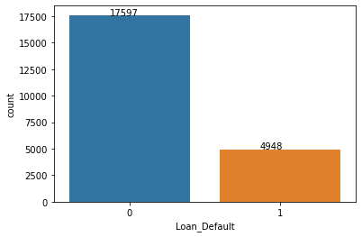

```python
# Lets see the ratio of target variable
plot = sns.countplot(x = df['Loan_Default'])
for bar in plot.patches:
    plot.annotate(format(bar.get_height(), '0.0f'),
                  (bar.get_x() + bar.get_width()/3, bar.get_height()),
                   size = 10)
```

```python
df.describe()
```

|  | Disbursed_Amount | Asset_Cost | ltv | Branch_Id | Postal_Code | MobileNo_Avl_Flag | Aadhar_flag | PAN_flag | VoterID_flag | Driving_flag | Passport_flag | PERFORM_CNS.SCORE | DELINQUENT.ACCTS.IN.LAST.SIX.MONTHS | NO.OF_INQUIRIES | Loan_Default | Year_of_birth | Age | DisburseDate | DisburseMonth | DisburseYear | credit_history_length_in_months |
| --- | --- | --- | --- | --- | --- | --- | --- | --- | --- | --- | --- | --- | --- | --- | --- | --- | --- | --- | --- | --- | --- |
| count | 22545.000000 | 22545.000000 | 22545.000000 | 22545.000000 | 22545.000000 | 22545.0 | 22545.000000 | 22545.000000 | 22545.000000 | 22545.000000 | 22545.000000 | 22545.000000 | 22545.000000 | 22545.000000 | 22545.000000 | 22545.000000 | 22545.000000 | 22545.000000 | 22545.000000 | 22545.0 | 22545.000000 |
| mean | 54189.803327 | 75598.875449 | 74.779085 | 72.175383 | 505641.092437 | 1.0 | 0.842626 | 0.077578 | 0.142959 | 0.023642 | 0.002129 | 295.117942 | 0.102417 | 0.208472 | 0.219472 | 1983.583943 | 35.416057 | 19.845686 | 9.121845 | 2018.0 | 16.509026 |
| std | 13017.784224 | 18860.695274 | 11.435777 | 69.292918 | 204719.988483 | 0.0 | 0.364161 | 0.267513 | 0.350038 | 0.151933 | 0.046094 | 338.983995 | 0.391338 | 0.704221 | 0.413898 | 9.643217 | 9.643217 | 8.257398 | 0.833459 | 0.0 | 28.687883 |
| min | 13369.000000 | 37230.000000 | 17.130000 | 1.000000 | 110039.000000 | 1.0 | 0.000000 | 0.000000 | 0.000000 | 0.000000 | 0.000000 | 0.000000 | 0.000000 | 0.000000 | 0.000000 | 1954.000000 | 21.000000 | 1.000000 | 8.000000 | 2018.0 | 0.000000 |
| 25% | 46849.000000 | 65528.000000 | 68.910000 | 13.000000 | 391510.000000 | 1.0 | 1.000000 | 0.000000 | 0.000000 | 0.000000 | 0.000000 | 0.000000 | 0.000000 | 0.000000 | 0.000000 | 1977.000000 | 27.000000 | 14.000000 | 8.000000 | 2018.0 | 0.000000 |
| 50% | 53693.000000 | 70794.000000 | 76.820000 | 61.000000 | 524225.000000 | 1.0 | 1.000000 | 0.000000 | 0.000000 | 0.000000 | 0.000000 | 15.000000 | 0.000000 | 0.000000 | 0.000000 | 1985.000000 | 34.000000 | 21.000000 | 9.000000 | 2018.0 | 0.000000 |
| 75% | 60213.000000 | 78999.000000 | 83.680000 | 121.000000 | 680503.000000 | 1.0 | 1.000000 | 0.000000 | 0.000000 | 0.000000 | 0.000000 | 680.000000 | 0.000000 | 0.000000 | 0.000000 | 1992.000000 | 42.000000 | 27.000000 | 10.000000 | 2018.0 | 24.000000 |
| max | 592460.000000 | 715186.000000 | 94.980000 | 261.000000 | 834008.000000 | 1.0 | 1.000000 | 1.000000 | 1.000000 | 1.000000 | 1.000000 | 890.000000 | 7.000000 | 23.000000 | 1.000000 | 1998.000000 | 65.000000 | 31.000000 | 10.000000 | 2018.0 | 349.000000 |

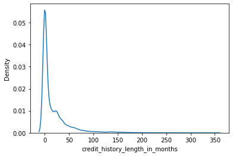

```python
sns.kdeplot(x = df['credit_history_length_in_months']);
```

**Observation : So we can see that the ration od default to non default is not equal**

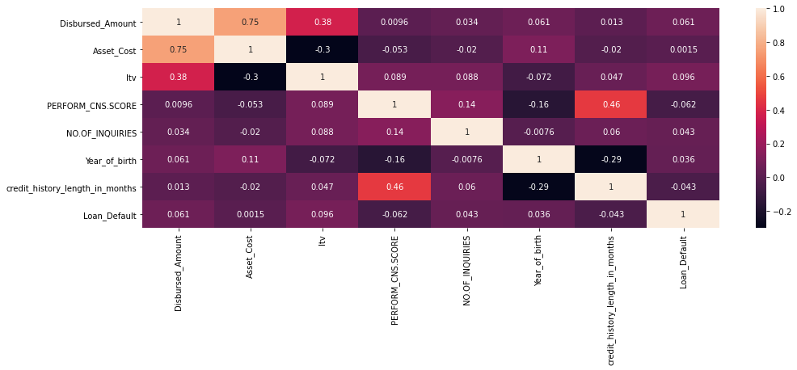

```python
plt.figure(figsize = (16, 5))
sns.heatmap(df[['Disbursed_Amount', 'Asset_Cost', 'ltv', 'PERFORM_CNS.SCORE', 'NO.OF_INQUIRIES', 'Year_of_birth',
                 'credit_history_length_in_months', 'Loan_Default']].corr(), annot = True)
```

- **From the above heatmap we can see that there is no corelation between Loan_Default and any other variables. So any Distance based ML Model or Logistic model will not be a good ML model for this data set.**
- But ensembled model and Decision Tree might perform good with this dataset.
- Lets make model and see how it performs.

```python
df.head()
```

|  | Disbursed_Amount | Asset_Cost | ltv | Branch_Id | Postal_Code | Employment_Type | MobileNo_Avl_Flag | Aadhar_flag | PAN_flag | VoterID_flag | Driving_flag | Passport_flag | PERFORM_CNS.SCORE | DELINQUENT.ACCTS.IN.LAST.SIX.MONTHS | NO.OF_INQUIRIES | Loan_Default | City_Name | State_Name | Year_of_birth | Age | DisburseDate | DisburseMonth | DisburseYear | credit_history_length_in_months |
| --- | --- | --- | --- | --- | --- | --- | --- | --- | --- | --- | --- | --- | --- | --- | --- | --- | --- | --- | --- | --- | --- | --- | --- | --- |
| 0 | 36439 | 65850 | 56.19 | 64 | 400001 | Self employed | 1 | 1 | 0 | 0 | 0 | 0 | 0 | 0 | 0 | 0 | Mumbai | Maharashtra | 1990 | 29 | 28 | 9 | 2018 | 0 |
| 1 | 48749 | 69303 | 72.15 | 67 | 600020 | Salaried | 1 | 1 | 0 | 0 | 0 | 0 | 783 | 0 | 0 | 0 | Chennai | Tamil Nadu | 1991 | 28 | 10 | 9 | 2018 | 30 |
| 2 | 55348 | 66340 | 85.00 | 2 | 801110 | Self employed | 1 | 1 | 0 | 0 | 0 | 0 | 0 | 0 | 0 | 1 | Patna | Bihar | 1993 | 26 | 31 | 8 | 2018 | 0 |
| 3 | 48849 | 64133 | 77.96 | 217 | 302029 | Self employed | 1 | 1 | 0 | 0 | 0 | 0 | 0 | 0 | 0 | 0 | Jaipur | Rajasthan | 1989 | 30 | 13 | 10 | 2018 | 0 |
| 4 | 40394 | 59386 | 70.72 | 74 | 600020 | Self employed | 1 | 1 | 0 | 0 | 0 | 0 | 14 | 1 | 1 | 0 | Chennai | Tamil Nadu | 1974 | 45 | 14 | 9 | 2018 | 37 |

```python
from sklearn.preprocessing import LabelEncoder
```

```python
lbe = LabelEncoder()
```

```python
df['City_Name'] = lbe.fit_transform(df['City_Name'].values.reshape(-1, 1))
df['State_Name'] = lbe.fit_transform(df['State_Name'].values.reshape(-1, 1))
```

```python
df['Employment_Type'] = lbe.fit_transform(df['Employment_Type'].values.reshape(-1, 1))
```

```python
df.head()
```

|  | Disbursed_Amount | Asset_Cost | ltv | Branch_Id | Postal_Code | Employment_Type | MobileNo_Avl_Flag | Aadhar_flag | PAN_flag | VoterID_flag | Driving_flag | Passport_flag | PERFORM_CNS.SCORE | DELINQUENT.ACCTS.IN.LAST.SIX.MONTHS | NO.OF_INQUIRIES | Loan_Default | City_Name | State_Name | Year_of_birth | Age | DisburseDate | DisburseMonth | DisburseYear | credit_history_length_in_months |
| --- | --- | --- | --- | --- | --- | --- | --- | --- | --- | --- | --- | --- | --- | --- | --- | --- | --- | --- | --- | --- | --- | --- | --- | --- |
| 0 | 36439 | 65850 | 56.19 | 64 | 400001 | 1 | 1 | 1 | 0 | 0 | 0 | 0 | 0 | 0 | 0 | 0 | 17 | 8 | 1990 | 29 | 28 | 9 | 2018 | 0 |
| 1 | 48749 | 69303 | 72.15 | 67 | 600020 | 0 | 1 | 1 | 0 | 0 | 0 | 0 | 783 | 0 | 0 | 0 | 4 | 13 | 1991 | 28 | 10 | 9 | 2018 | 30 |
| 2 | 55348 | 66340 | 85.00 | 2 | 801110 | 1 | 1 | 1 | 0 | 0 | 0 | 0 | 0 | 0 | 0 | 1 | 21 | 1 | 1993 | 26 | 31 | 8 | 2018 | 0 |
| 3 | 48849 | 64133 | 77.96 | 217 | 302029 | 1 | 1 | 1 | 0 | 0 | 0 | 0 | 0 | 0 | 0 | 0 | 11 | 11 | 1989 | 30 | 13 | 10 | 2018 | 0 |
| 4 | 40394 | 59386 | 70.72 | 74 | 600020 | 1 | 1 | 1 | 0 | 0 | 0 | 0 | 14 | 1 | 1 | 0 | 4 | 13 | 1974 | 45 | 14 | 9 | 2018 | 37 |

## Statistical technique for feature selection.

### Univariate Selection

```python
from sklearn.feature_selection import SelectKBest
from sklearn.feature_selection import chi2
X = df.drop('Loan_Default', axis = 1) # independaent varibles
Y = df['Loan_Default'] # dependant varieble
```

```python
# apply SlectionKbest class to exctract top feautres
bestfeatures = SelectKBest(score_func = chi2, k = 5)
fit = bestfeatures.fit(X, Y)
```

```python
dfscores = pd.DataFrame(fit.scores_)
dfcolumns = pd.DataFrame(X.columns)
```

```python
# Conncat two datframe for better visualization
featureScores = pd.concat([dfcolumns, dfscores], axis = 1)
featureScores.columns = ['Attributes', 'Score']
```

```python
## arranging Important features in decending of there score
featureScores.sort_values(by = ['Score'], ascending = False)
```

|  | Attributes | Score |
| --- | --- | --- |
| 0 | Disbursed_Amount | 265191.813128 |
| 4 | Postal_Code | 56779.726360 |
| 12 | PERFORM_CNS.SCORE | 34195.324782 |
| 3 | Branch_Id | 2236.492954 |
| 22 | credit_history_length_in_months | 2039.977300 |
| 2 | ltv | 360.361151 |
| 1 | Asset_Cost | 235.179448 |
| 14 | NO.OF_INQUIRIES | 97.014869 |
| 18 | Age | 78.399122 |
| 9 | VoterID_flag | 49.694534 |
| 19 | DisburseDate | 45.553557 |
| 15 | City_Name | 36.890303 |
| 13 | DELINQUENT.ACCTS.IN.LAST.SIX.MONTHS | 35.945388 |
| 7 | Aadhar_flag | 10.438976 |
| 5 | Employment_Type | 9.048286 |
| 16 | State_Name | 5.512295 |
| 11 | Passport_flag | 2.500813 |
| 8 | PAN_flag | 1.636524 |
| 17 | Year_of_birth | 1.399783 |
| 20 | DisburseMonth | 1.171013 |
| 10 | Driving_flag | 0.704690 |
| 6 | MobileNo_Avl_Flag | 0.000000 |
| 21 | DisburseYear | 0.000000 |

```python
print(featureScores.nlargest(15, 'Score'))
```

```
                             Attributes          Score
0                      Disbursed_Amount  265191.813128
4                           Postal_Code   56779.726360
12                    PERFORM_CNS.SCORE   34195.324782
3                             Branch_Id    2236.492954
22      credit_history_length_in_months    2039.977300
2                                   ltv     360.361151
1                            Asset_Cost     235.179448
14                      NO.OF_INQUIRIES      97.014869
18                                  Age      78.399122
9                          VoterID_flag      49.694534
19                         DisburseDate      45.553557
15                            City_Name      36.890303
13  DELINQUENT.ACCTS.IN.LAST.SIX.MONTHS      35.945388
7                           Aadhar_flag      10.438976
5                       Employment_Type       9.048286
```

```python
list(featureScores.nlargest(15, 'Score')['Attributes'])
```

```
['Disbursed_Amount',
 'Postal_Code',
 'PERFORM_CNS.SCORE',
 'Branch_Id',
 'credit_history_length_in_months',
 'ltv',
 'Asset_Cost',
 'NO.OF_INQUIRIES',
 'Age',
 'VoterID_flag',
 'DisburseDate',
 'City_Name',
 'DELINQUENT.ACCTS.IN.LAST.SIX.MONTHS',
 'Aadhar_flag',
 'Employment_Type']
```

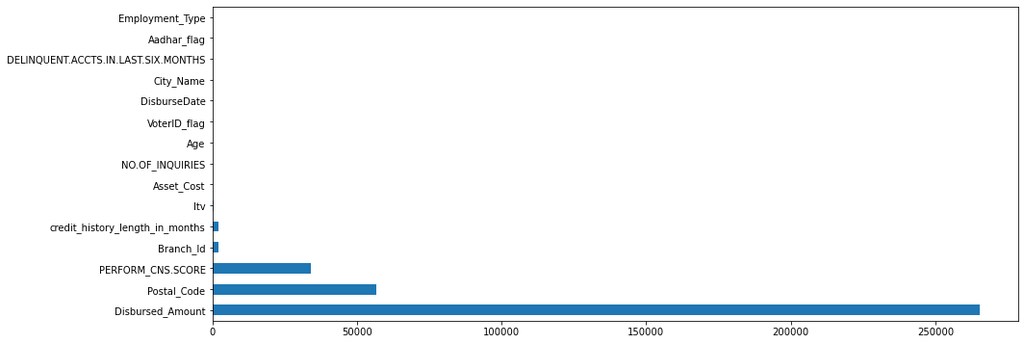

```python
# plotting Feature importance of top 15 attributes
plt.figure(figsize = (15, 6))
feat_importances = pd.Series(list(featureScores.nlargest(15, 'Score')['Score']), index = list(featureScores.nlargest(15, 'Score')['Attributes']))
feat_importances.nlargest(15).plot(kind = 'barh')
plt.show()
```

*Now, we have got the most important features for the prediction of output variable. We'll remove all redudant varible and then build models.*

```python
list(featureScores.nlargest(15, 'Score')['Attributes'])
```

```
['Disbursed_Amount',
 'Postal_Code',
 'PERFORM_CNS.SCORE',
 'Branch_Id',
 'credit_history_length_in_months',
 'ltv',
 'Asset_Cost',
 'NO.OF_INQUIRIES',
 'Age',
 'VoterID_flag',
 'DisburseDate',
 'City_Name',
 'DELINQUENT.ACCTS.IN.LAST.SIX.MONTHS',
 'Aadhar_flag',
 'Employment_Type']
```

```python
X_new = X[list(featureScores.nlargest(15, 'Score')['Attributes'])]
X_new.head()
```

|  | Disbursed_Amount | Postal_Code | PERFORM_CNS.SCORE | Branch_Id | credit_history_length_in_months | ltv | Asset_Cost | NO.OF_INQUIRIES | Age | VoterID_flag | DisburseDate | City_Name | DELINQUENT.ACCTS.IN.LAST.SIX.MONTHS | Aadhar_flag | Employment_Type |
| --- | --- | --- | --- | --- | --- | --- | --- | --- | --- | --- | --- | --- | --- | --- | --- |
| 0 | 36439 | 400001 | 0 | 64 | 0 | 56.19 | 65850 | 0 | 29 | 0 | 28 | 17 | 0 | 1 | 1 |
| 1 | 48749 | 600020 | 783 | 67 | 30 | 72.15 | 69303 | 0 | 28 | 0 | 10 | 4 | 0 | 1 | 0 |
| 2 | 55348 | 801110 | 0 | 2 | 0 | 85.00 | 66340 | 0 | 26 | 0 | 31 | 21 | 0 | 1 | 1 |
| 3 | 48849 | 302029 | 0 | 217 | 0 | 77.96 | 64133 | 0 | 30 | 0 | 13 | 11 | 0 | 1 | 1 |
| 4 | 40394 | 600020 | 14 | 74 | 37 | 70.72 | 59386 | 1 | 45 | 0 | 14 | 4 | 1 | 1 | 1 |

# Model building

### Smote

```python
from imblearn.over_sampling import SMOTE
```

```python
sm = SMOTE(random_state = 3)
```

```python
OversampledX, OversampledY = sm.fit_resample(X_new, Y)
```

```python
## Checking the data is balance or not after SMOTE
OversampledY.value_counts(normalize = True)
```

```
0    0.5
1    0.5
Name: Loan_Default, dtype: float64
```

### Train Test Split

```python
#Train-Test split
from sklearn.model_selection import train_test_split
```

```python
Xtrain, Xtest, Ytrain, Ytest = train_test_split(OversampledX, OversampledY, test_size=0.2, random_state=1)
```

```python
Ytrain.value_counts(normalize = True)
```

```
1    0.500053
0    0.499947
Name: Loan_Default, dtype: float64
```

*Our data is balanced, now we can apply model.*

### Decision Tree classifier

```python
from sklearn.tree import DecisionTreeClassifier
decision_tree = DecisionTreeClassifier()
```

*Here we are using HalvingGridSerchCV instead of GriDSearchCV becuse the execution time of HalvingGridSearchCV is 25 time less that normal GridSearchCV.*

```python
from sklearn.experimental import enable_halving_search_cv
from sklearn.model_selection import HalvingGridSearchCV
from sklearn.metrics import plot_confusion_matrix,confusion_matrix
```

```python
halving_cv  = HalvingGridSearchCV(decision_tree, param_grid={'max_depth':[i for i in range(6, 17)],
                                              'max_leaf_nodes':[i for i in range(9, 16)],
                                              'min_samples_leaf':[i for i in range(10,200,5)],
                                              'criterion' :['gini']},cv =10)
```

```python
halving_cv.fit(Xtrain, Ytrain)
```

```
HalvingGridSearchCV(cv=10, estimator=DecisionTreeClassifier(),
                    param_grid={'criterion': ['gini'],
                                'max_depth': [6, 7, 8, 9, 10, 11, 12, 13, 14,
                                              15, 16],
                                'max_leaf_nodes': [9, 10, 11, 12, 13, 14, 15],
                                'min_samples_leaf': [10, 15, 20, 25, 30, 35, 40,
                                                     45, 50, 55, 60, 65, 70, 75,
                                                     80, 85, 90, 95, 100, 105,
                                                     110, 115, 120, 125, 130,
                                                     135, 140, 145, 150, 155, ...]})
```

```python
## Best accuracy we got using
print('Best accuracy by decision Tree Classifier is ',halving_cv.best_score_)
```

```
Best accuracy by decision Tree Classifier is  0.6986125414807185
```

```python
print('Best params for model is ', halving_cv.best_params_)
```

```
Best params for model is  {'criterion': 'gini', 'max_depth': 9, 'max_leaf_nodes': 14, 'min_samples_leaf': 15}
```

```python
decision_tree = DecisionTreeClassifier(max_depth = 10, max_leaf_nodes = 22, min_samples_leaf = 25)
decision_tree.fit(Xtrain, Ytrain)
```

```
DecisionTreeClassifier(max_depth=10, max_leaf_nodes=22, min_samples_leaf=25)
```

#### Model Evaluation

```python
from sklearn.metrics import precision_score,accuracy_score,recall_score,roc_curve,roc_auc_score,auc
from sklearn.metrics import classification_report
```

```python
# Predicted test
Ypred_test = decision_tree.predict(Xtest)
```

```python
# Predicted train
Ypred_train = decision_tree.predict(Xtrain)
```

```python
# Training accuracy
print('Training accuracy  is ', accuracy_score(Ytrain, Ypred_train))
```

```
Training accuracy  is  0.7167820990942995
```

```python
# Testing accuracy
print('Testing accuracy is', accuracy_score(Ytest, Ypred_test))
```

```
Testing accuracy is 0.7103281716152863
```

*As the test accuracy is less thatn training accuracy, but the difference is not too much we can say that the model is neither ovefit nor underfit.*

```python
print(classification_report(Ytest, Ypred_test))
```

```
              precision    recall  f1-score   support

           0       0.67      0.83      0.74      3521
           1       0.78      0.59      0.67      3518

    accuracy                           0.71      7039
   macro avg       0.72      0.71      0.71      7039
weighted avg       0.72      0.71      0.71      7039
```

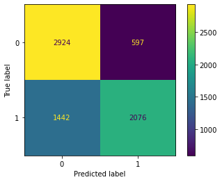

```python
#Plotiign confusion matrix

plot_confusion_matrix(decision_tree, Xtest, Ytest)
plt.show()
```

```python
prob = decision_tree.predict_proba(Xtest)[:, 1]
prob
```

```
array([0.41440378, 0.87858572, 1.        , ..., 0.32983901, 0.52510587,
       0.33068081])
```

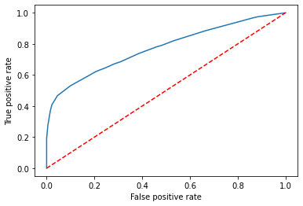

```python
from sklearn.metrics import roc_curve,roc_auc_score

fpr,tpr,threshold = roc_curve(Ytest, prob)
plt.plot(fpr,tpr)
plt.plot([0,1],[0,1],color='r',ls='--')
plt.xlabel('False positive rate')
plt.ylabel('True positive rate')
```

**NOTE :**

- *As we have used the HalvingGridSerchCv the accuracy of model is slightly low than what we get bu GridSerchCV but the execution time is far less so we used HalvingGridSerchCV.* -- Here, we have traded little accuracy for far less execution time. -- But if our objective is to achieve higher accuracy and we do not care about the long execuation time we'll go with GridSearchCV.

### Random Forest (ensembled model)

```python
from sklearn.ensemble import RandomForestClassifier
```

```python
Random_forest = RandomForestClassifier(oob_score = True, n_estimators = 150, random_state = 30)
Random_forest.fit(Xtrain, Ytrain)
```

```
RandomForestClassifier(n_estimators=150, oob_score=True, random_state=30)
```

```python
Random_forest.oob_score_
```

```
0.8090214881903747
```

*Here also, we can apply Halving GridSearchCV to get best parameters. But it will take more time so for the now we'll try to pruning maually*

```python
Random_forest = RandomForestClassifier()
```

```python
Random_forest = RandomForestClassifier(n_estimators = 10, max_depth = 13, random_state = 30, max_leaf_nodes = 18)
```

```python
Random_forest.fit(Xtrain, Ytrain)
```

```
RandomForestClassifier(max_depth=13, max_leaf_nodes=18, n_estimators=10,
                       random_state=30)
```

#### Model Eval

```python
# Predict test
Ypred_test = Random_forest.predict(Xtest)

# Predicted train
Ypred_train = Random_forest.predict(Xtrain)
```

```python
# Training accuracy
print('Training accuracy  is ', accuracy_score(Ytrain, Ypred_train))

# Testing accuracy
print('Testing  accuracy  is ', accuracy_score(Ytest, Ypred_test))
```

```
Training accuracy  is  0.7112058248978868
Testing  accuracy  is  0.7059241369512715
```

*Here as the training accuracy and test accuracy difference is not much so the model is well generalized.*

```python
## Classification report
print(classification_report(Ytest, Ypred_test))
```

```
              precision    recall  f1-score   support

           0       0.67      0.81      0.73      3521
           1       0.76      0.60      0.67      3518

    accuracy                           0.71      7039
   macro avg       0.72      0.71      0.70      7039
weighted avg       0.72      0.71      0.70      7039
```

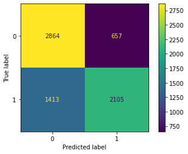

```python
#Plotiign confusion matrix

plot_confusion_matrix(Random_forest, Xtest, Ytest)
plt.show()
```

```python
prob = Random_forest.predict_proba(Xtest)[:, 1]
prob
```

```
array([0.76562132, 0.67017139, 0.67319465, ..., 0.38934904, 0.44869494,
       0.3887146 ])
```

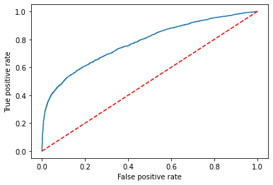

```python
fpr,tpr,threshold = roc_curve(Ytest, prob)
plt.plot(fpr,tpr)
plt.plot([0,1],[0,1],color='r',ls='--')
plt.xlabel('False positive rate')
plt.ylabel('True positive rate')
```

**NOTE :**

- *Here, also we can use Crossvalidation to improve accuracy. But we have done it manually because of the time constraint.* -- But if our objective is to achieve higher accuracy and we do not care about the long execuation time we'll go with Crossvalidation.

### Bagging (ensembled)

```python
from sklearn.ensemble import BaggingClassifier
```

```python
Bagging = BaggingClassifier(oob_score=True, n_estimators= 130 ,
                            base_estimator = DecisionTreeClassifier(max_depth = 30,
                                                                    max_leaf_nodes = 55,
                                                                    min_samples_leaf = 35),
                            random_state = 30)
Bagging.fit(Xtrain, Ytrain)
```

```
BaggingClassifier(base_estimator=DecisionTreeClassifier(max_depth=30,
                                                        max_leaf_nodes=55,
                                                        min_samples_leaf=35),
                  n_estimators=130, oob_score=True, random_state=30)
```

#### Model Eval

```python
# Predict test
Ypred_test = Bagging.predict(Xtest)

# Predict train
Ypred_train = Bagging.predict(Xtrain)
```

```python
# Training accuracy
print('Training accuracy  is ', accuracy_score(Ytrain, Ypred_train))

# Test accuracy
print('Testing  accuracy  is ', accuracy_score(Ytest, Ypred_test))
```

```
Training accuracy  is  0.7497424968922038
Testing  accuracy  is  0.7391674953828669
```

*Here as the training accuracy and test accuracy difference is not much so the model is well generalized.*

```python
## Classification report
print(classification_report(Ytest, Ypred_test))
```

```
              precision    recall  f1-score   support

           0       0.68      0.89      0.77      3521
           1       0.85      0.58      0.69      3518

    accuracy                           0.74      7039
   macro avg       0.76      0.74      0.73      7039
weighted avg       0.76      0.74      0.73      7039
```

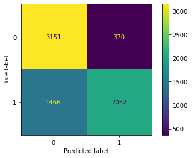

```python
#Plotiign confusion matrix

plot_confusion_matrix(Bagging, Xtest, Ytest)
plt.show()
```

```python
prob = Bagging.predict_proba(Xtest)[:, 1]
prob
```

```
array([0.45599435, 0.89020779, 0.99880417, ..., 0.22800857, 0.52774019,
       0.31603212])
```

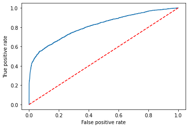

```python
fpr,tpr,threshold = roc_curve(Ytest, prob)
plt.plot(fpr,tpr)
plt.plot([0,1],[0,1],color='r',ls='--')
plt.xlabel('False positive rate')
plt.ylabel('True positive rate')
```

**NOTE :**

- *Here, also we can use Crossvalidation to improve accuracy. But we have done it manually because of the time constraint.* -- But if our objective is to achieve higher accuracy and we do not care about the long execuation time we'll go with Crossvalidation which will find best model.

## Adaboost (ensembled)

```python
from sklearn.ensemble import AdaBoostClassifier
```

```python
Ada_boost = AdaBoostClassifier(n_estimators = 120, random_state = 100,
                              base_estimator = DecisionTreeClassifier(max_depth = 35, max_leaf_nodes = 38, min_samples_leaf = 15),
                              learning_rate = 0.1)
Ada_boost.fit(Xtrain, Ytrain)
```

```
AdaBoostClassifier(base_estimator=DecisionTreeClassifier(max_depth=35,
                                                         max_leaf_nodes=38,
                                                         min_samples_leaf=15),
                   learning_rate=0.1, n_estimators=120, random_state=100)
```

#### Model eval

```python
# Predict test
Ypred_test = Ada_boost.predict(Xtest)

# Predict train
Ypred_train = Ada_boost.predict(Xtrain)
```

```python
# Training accuracy
print('Training accuracy  is ', accuracy_score(Ytrain, Ypred_train))

# Test accuracy
print('Testing  accuracy  is ', accuracy_score(Ytest, Ypred_test))
```

```
Training accuracy  is  0.8464571124134257
Testing  accuracy  is  0.7964199460150589
```

*Here as the training accuracy and test accuracy difference is not much so the model is well generalized.*

```python
## Classification report
print(classification_report(Ytest, Ypred_test))
```

```
              precision    recall  f1-score   support

           0       0.74      0.92      0.82      3521
           1       0.89      0.67      0.77      3518

    accuracy                           0.80      7039
   macro avg       0.82      0.80      0.79      7039
weighted avg       0.82      0.80      0.79      7039
```

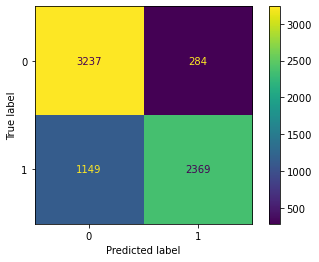

```python
#Plotiign confusion matrix

plot_confusion_matrix(Ada_boost, Xtest, Ytest)
plt.show()
```

```python
prob = Ada_boost.predict_proba(Xtest)[:, 1]
prob
```

```
array([0.60650775, 0.55486575, 0.82207622, ..., 0.36949591, 0.48545246,
       0.47918062])
```

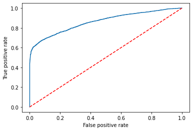

```python
fpr,tpr,threshold = roc_curve(Ytest, prob)
plt.plot(fpr,tpr)
plt.plot([0,1],[0,1],color='r',ls='--')
plt.xlabel('False positive rate')
plt.ylabel('True positive rate')
```

**NOTE :**

- *Here, also we can use Crossvalidation to improve accuracy. But we have done it manually because of the time constraint.*
- But if our objective is to achieve higher accuracy and we do not care about the long execuation time we'll go with Crossvalidation which will find best model.

## Gradient Boost

```python
from sklearn.ensemble import GradientBoostingClassifier
```

```python
Gradient_boost =  GradientBoostingClassifier(n_estimators=715, random_state=100, validation_fraction = 0.12,
                                            max_features = 8, learning_rate = 0.11)
Gradient_boost.fit(Xtrain, Ytrain)
```

```
GradientBoostingClassifier(learning_rate=0.11, max_features=8, n_estimators=715,
                           random_state=100, validation_fraction=0.12)
```

#### Model eval

```python
# Predicted test
Ypred_test = Gradient_boost.predict(Xtest)

# Predicted Train
Ypred_train = Gradient_boost.predict(Xtrain)
```

```python
# Train Accuracy
print('Train accuracy is ',accuracy_score(Ytrain, Ypred_train))

# Test Accuracy
print('Test  accuracy is ',accuracy_score(Ytest, Ypred_test))
```

```
Train accuracy is  0.8259989344698988
Test  accuracy is  0.791589714448075
```

*Here as the training accuracy and test accuracy difference is not much so the model is well generalized.*

```python
## Classification report
print(classification_report(Ytest, Ypred_test))
```

```
              precision    recall  f1-score   support

           0       0.74      0.89      0.81      3521
           1       0.86      0.69      0.77      3518

    accuracy                           0.79      7039
   macro avg       0.80      0.79      0.79      7039
weighted avg       0.80      0.79      0.79      7039
```

[figure not shown]

```python
#Plotiign confusion matrix

plot_confusion_matrix(Ada_boost, Xtest, Ytest)
plt.show()
```

```python
prob = Gradient_boost.predict_proba(Xtest)[:, 1]
prob
```

```
array([0.97409986, 0.75893256, 0.99298685, ..., 0.11300114, 0.18669869,
       0.17128075])
```

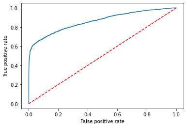

```python
fpr,tpr,threshold = roc_curve(Ytest, prob)
plt.plot(fpr,tpr)
plt.plot([0,1],[0,1],color='r',ls='--')
plt.xlabel('False positive rate')
plt.ylabel('True positive rate')
```

**NOTE :**

- *Here, also we can use Crossvalidation to improve accuracy. But we have done it manually because of the time constraint.*
- But if our objective is to achieve higher accuracy and we do not care about the long execuation time we'll go with Crossvalidation which will find best model.

## XGBoost

```python
import xgboost as xgb
```

```python
Xgboost = xgb.XGBClassifier(n_estimators = 50, max_depth = 8, min_child_weight = 15,
                           learning_rate = 0.12, booster = 'gbtree', random_state = 4)

Xgboost.fit(Xtrain, Ytrain)
```

[output not shown]

```
XGBClassifier(base_score=0.5, booster='gbtree', colsample_bylevel=1,
              colsample_bynode=1, colsample_bytree=1, enable_categorical=False,
              gamma=0, gpu_id=-1, importance_type=None,
              interaction_constraints='', learning_rate=0.12, max_delta_step=0,
              max_depth=8, min_child_weight=15, missing=nan,
              monotone_constraints='()', n_estimators=50, n_jobs=4,
              num_parallel_tree=1, predictor='auto', random_state=4,
              reg_alpha=0, reg_lambda=1, scale_pos_weight=1, subsample=1,
              tree_method='exact', validate_parameters=1, verbosity=None)
```

#### Model eval

```python
# Test predict
Ypred_test = Xgboost.predict(Xtest)

# Train predict
Ypred_train = Xgboost.predict(Xtrain)
```

```python
# Train Accuracy
print('Train accuracy is ',accuracy_score(Ytrain, Ypred_train))

# Test Accuracy
print('Test  accuracy is ',accuracy_score(Ytest, Ypred_test))
```

```
Train accuracy is  0.8204581779435269
Test  accuracy is  0.7851967609035374
```

*Here as the training accuracy and test accuracy difference is not much so the model is well generalized.*

```python
## Classification report
print(classification_report(Ytest, Ypred_test))
```

```
              precision    recall  f1-score   support

           0       0.74      0.89      0.81      3521
           1       0.86      0.68      0.76      3518

    accuracy                           0.79      7039
   macro avg       0.80      0.79      0.78      7039
weighted avg       0.80      0.79      0.78      7039
```

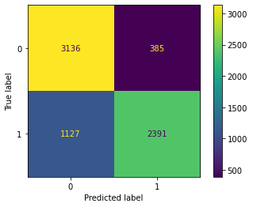

```python
#Plotiign confusion matrix

plot_confusion_matrix(Xgboost, Xtest, Ytest)
plt.show()
```

```python
prob = Xgboost.predict_proba(Xtest)[:, 1]
prob
```

```
array([0.7379157 , 0.8605316 , 0.978392  , ..., 0.13434963, 0.40962255,
       0.19423486], dtype=float32)
```

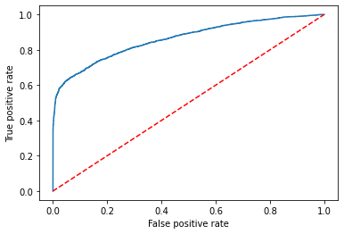

```python
fpr,tpr,threshold = roc_curve(Ytest, prob)
plt.plot(fpr,tpr)
plt.plot([0,1],[0,1],color='r',ls='--')
plt.xlabel('False positive rate')
plt.ylabel('True positive rate')
```

**NOTE :**

- *Here, also we can use Crossvalidation to improve accuracy. But we have done it manually because of the time constraint.*
- But if our objective is to achieve higher accuracy and we do not care about the long execuation time we'll go with Crossvalidation which will find best model.

## Now we'll move towards Distance based models.

```python
X_new.head()
```

|  | Disbursed_Amount | Postal_Code | PERFORM_CNS.SCORE | Branch_Id | credit_history_length_in_months | ltv | Asset_Cost | NO.OF_INQUIRIES | Age | VoterID_flag | DisburseDate | City_Name | DELINQUENT.ACCTS.IN.LAST.SIX.MONTHS | Aadhar_flag | Employment_Type |
| --- | --- | --- | --- | --- | --- | --- | --- | --- | --- | --- | --- | --- | --- | --- | --- |
| 0 | 36439 | 400001 | 0 | 64 | 0 | 56.19 | 65850 | 0 | 29 | 0 | 28 | 17 | 0 | 1 | 1 |
| 1 | 48749 | 600020 | 783 | 67 | 30 | 72.15 | 69303 | 0 | 28 | 0 | 10 | 4 | 0 | 1 | 0 |
| 2 | 55348 | 801110 | 0 | 2 | 0 | 85.00 | 66340 | 0 | 26 | 0 | 31 | 21 | 0 | 1 | 1 |
| 3 | 48849 | 302029 | 0 | 217 | 0 | 77.96 | 64133 | 0 | 30 | 0 | 13 | 11 | 0 | 1 | 1 |
| 4 | 40394 | 600020 | 14 | 74 | 37 | 70.72 | 59386 | 1 | 45 | 0 | 14 | 4 | 1 | 1 | 1 |

```python
Y
```

```
0        0
1        0
2        1
3        0
4        0
        ..
23310    0
23311    0
23312    0
23313    0
23314    0
Name: Loan_Default, Length: 22545, dtype: int64
```

```python
X_new['DELINQUENT.ACCTS.IN.LAST.SIX.MONTHS'].value_counts()
```

```
0    20708
1     1500
2      252
3       58
4       12
5        9
6        4
7        2
Name: DELINQUENT.ACCTS.IN.LAST.SIX.MONTHS, dtype: int64
```

```python
## Displaying only top 10 important features
top_10_features = featureScores.nlargest(10, 'Score')
top_10_features
```

|  | Attributes | Score |
| --- | --- | --- |
| 0 | Disbursed_Amount | 265191.813128 |
| 4 | Postal_Code | 56779.726360 |
| 12 | PERFORM_CNS.SCORE | 34195.324782 |
| 3 | Branch_Id | 2236.492954 |
| 22 | credit_history_length_in_months | 2039.977300 |
| 2 | ltv | 360.361151 |
| 1 | Asset_Cost | 235.179448 |
| 14 | NO.OF_INQUIRIES | 97.014869 |
| 18 | Age | 78.399122 |
| 9 | VoterID_flag | 49.694534 |

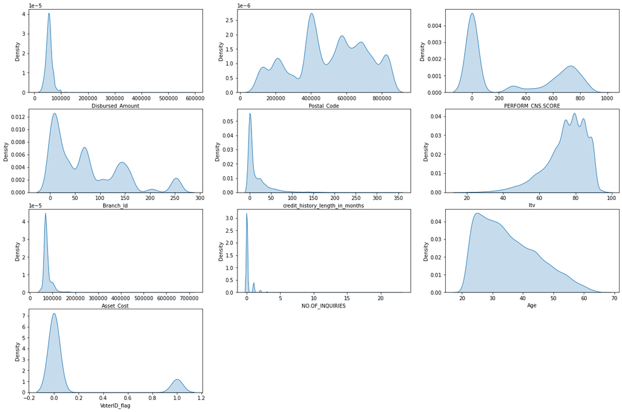

```python
# Checking the Outliers in Top 10 features
plt.figure(figsize = (21, 14))

for n, i in enumerate(top_10_features['Attributes']):
    plt.subplot(4, 3, n+1)
    ax1 = sns.kdeplot(X_new[i], shade = True)
```

- *So here we can see all the top 10 most important feature's kdeplots.*
- *We can see that many features are skewed so we need to transform the data to before applying Linear Regression model.*

```python
X_copy = X_new[list(top_10_features['Attributes'])].copy()
```

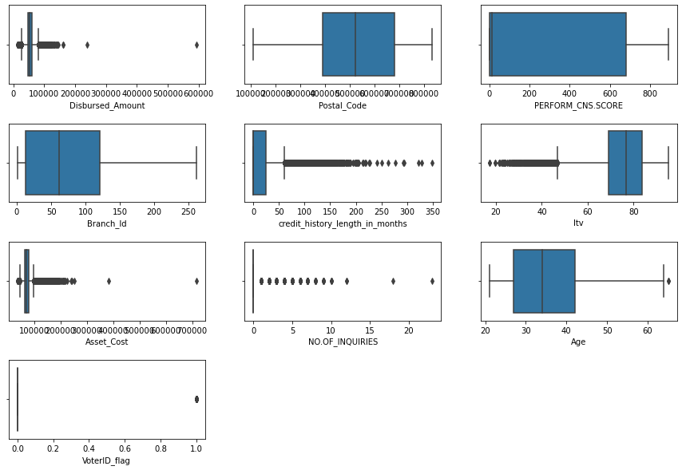

```python
plt.figure(figsize=(15, 10))
plt.subplots_adjust(hspace=0.5)

for n, i in enumerate(top_10_features['Attributes']):
    ax = plt.subplot(4, 3, n+1)

    sns.boxplot(X_new[i])
```

- *So here we can see all the top 10 most important feature's boxplots.*
- *We can see that there are lots of outliers which will impact Linear regression model and KNN model.*